# Отчет по лабораторной работе №11

Текстовой редактор emacs

Виноградова М.А

Российский университет дружбы народов, Москва, Россия

25 апреля 2025

# Информация

## Докладчик

- Виноградова Мария Андреевна
- студентка НПИбд-01-24
- номер студ. билета 1132240691
- Российский университет дружбы народов
- 1132240691@pfur.ru
- https://github.com/mavinogradova/study_2024-2025_os-intro

# Цель работы

Познакомиться с операционной системой Linux. Получить практические навыки работы с редактором Emacs.

# Задание

1. Ознакомиться с теоретическим материалом.
2. Ознакомиться с редактором emacs.
3. Выполнить упражнения.
4. Ответить на контрольные вопросы.

# Выполнение лабораторной работы

## Выполнение упражнения

## 2. Скачиваем emacs.

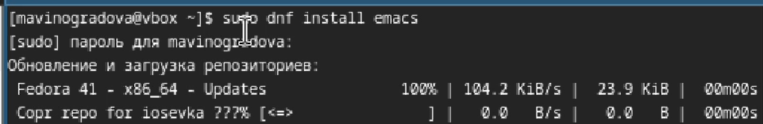

Скачиваем emacs

## 1. Открыть emacs.

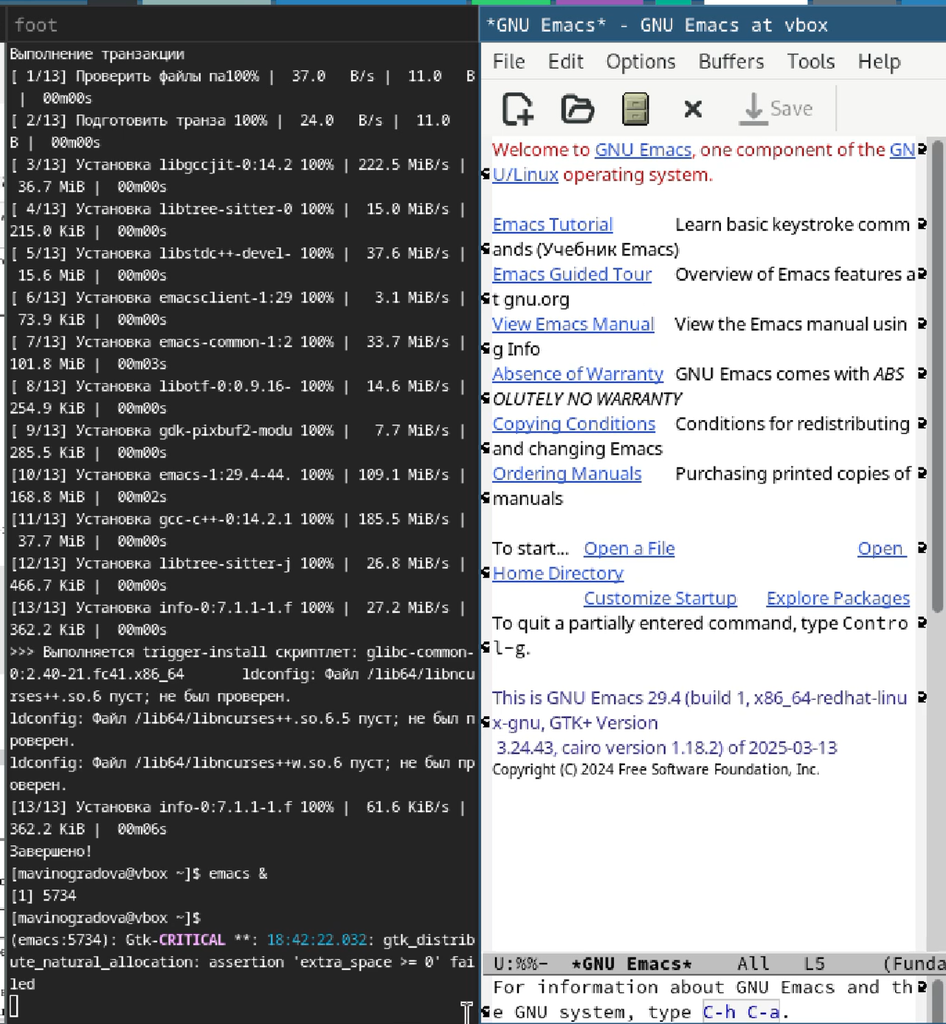

Открываем emacs

## 2. Создать файл lab07.sh с помощью комбинации Ctrl-x Ctrl-f

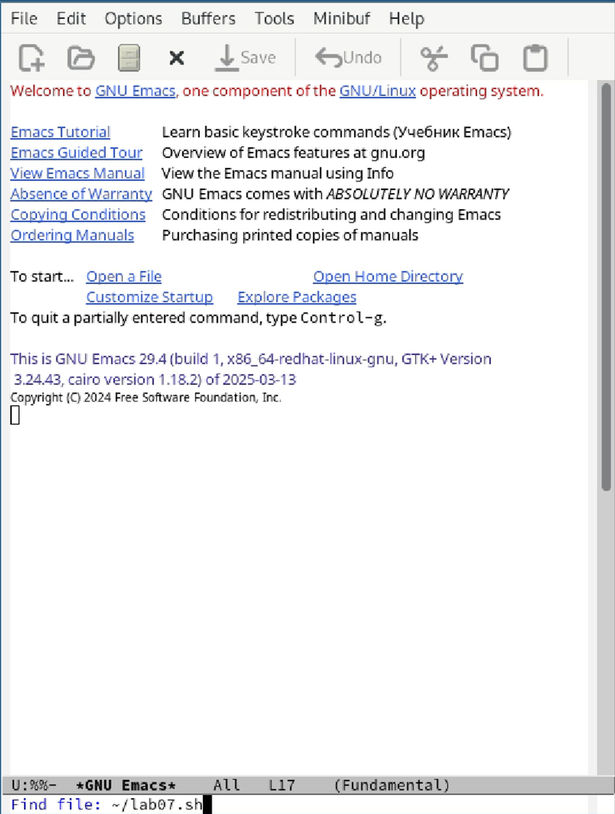

Создаем файл lab07.sh

## 3. Наберите текст.

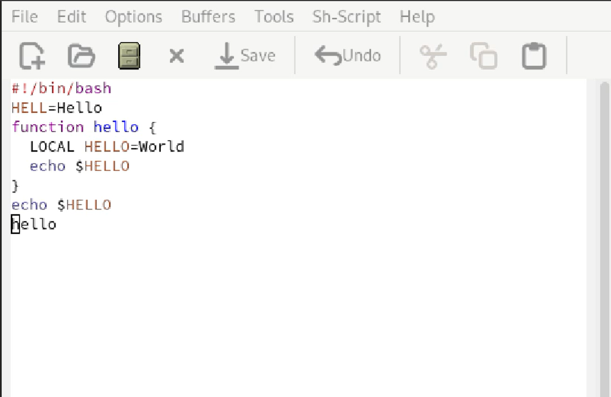

Набираем текст

## 4. Сохранить файл с помощью комбинации Ctrl-x Ctrl-s

## 5. Проделать с текстом стандартные процедуры редактирования, каждое действие должно осуществляться комбинацией клавиш:

## 5.1. Вырезать одной командой целую строку (С-k).

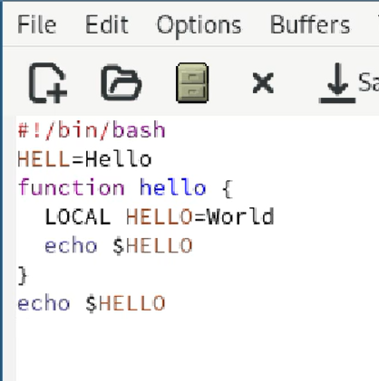

Вырезаем строку

## 5.2. Вставить эту строку в конец файла (C-y).

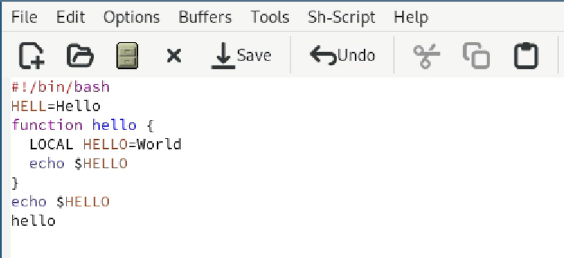

Вставляем строку

## 5.3. Выделить область текста (C-space).

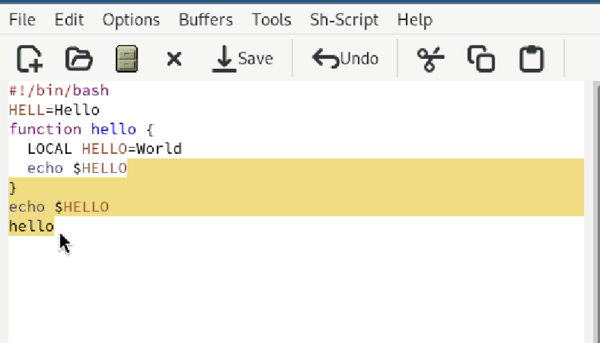

Выделяем область текста

## 5.4. Скопировать область в буфер обмена (M-w).

## 5.5. Вставить область в конец файла.

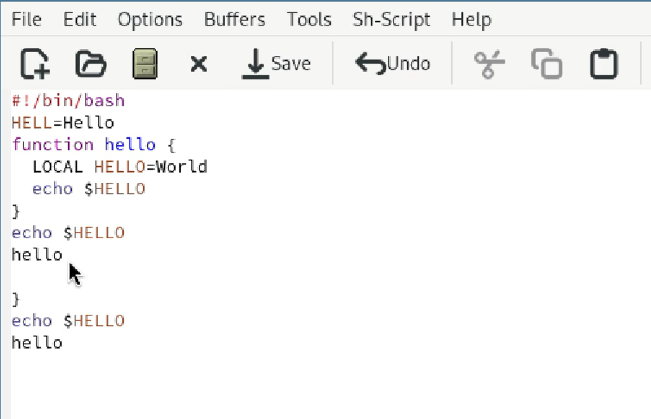

Вставляем область текста в конец файла

## 5.6. Вновь выделить эту область и на этот раз вырезать её

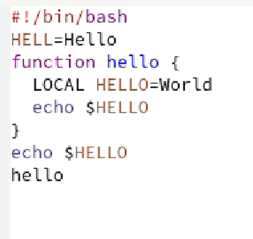

Вновь выделяем область и вырезаем её

## 5.7. Отмените последнее действие (C-/).

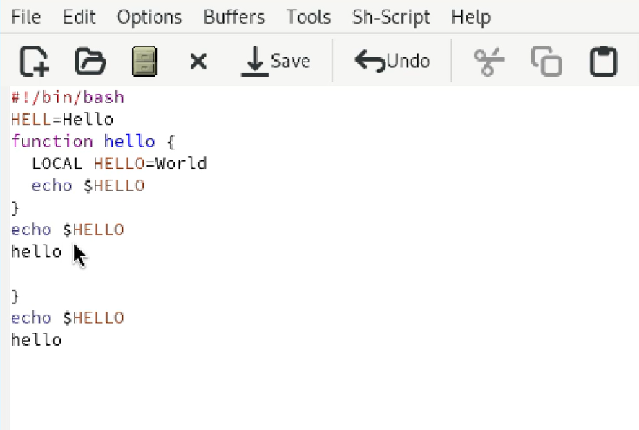

Отменяем последнее действие

## 6. Научитесь использовать команды по перемещению курсора.

## 6.1. Переместите курсор в начало строки (C-a)

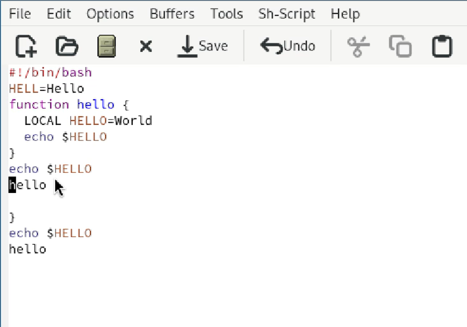

Перемещаем курсор в начало строки

## 6.2. Переместите курсор в конец строки (C-e)

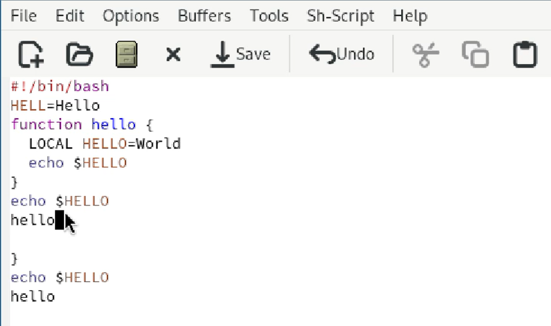

Перемещаем курсор в конец строки

## 6.3. Переместите курсор в начало буфера (M-<).

[figure not shown]

## 6.4. Переместите курсор в конец буфера (M->).

## 7. Управление буферами.

## 7.1. Вывести список активных буферов на экран (C-x C-b).

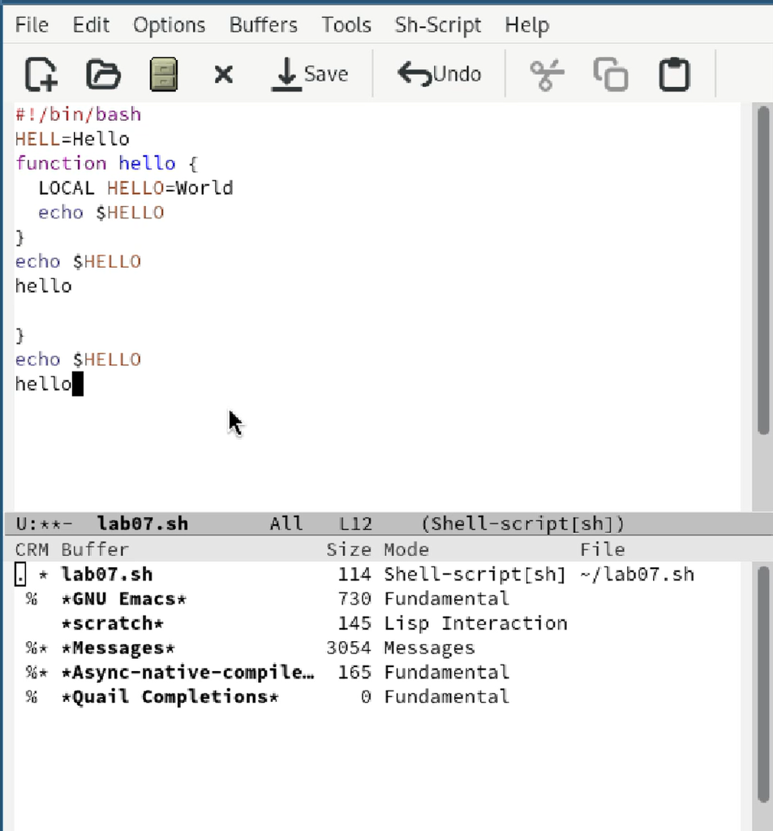

Выводим список активных буферов на экран

## 7.2. Переместитесь во вновь открытое окно (C-x) o со списком открытых буферов и переключитесь на другой буфер.

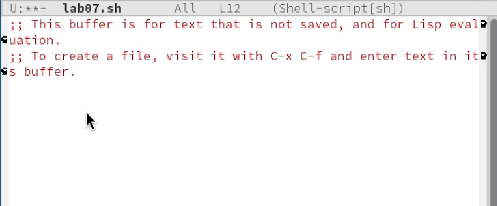

Переключаемся на другой буфер

## 7.3. Закройте это окно (C-x 0).

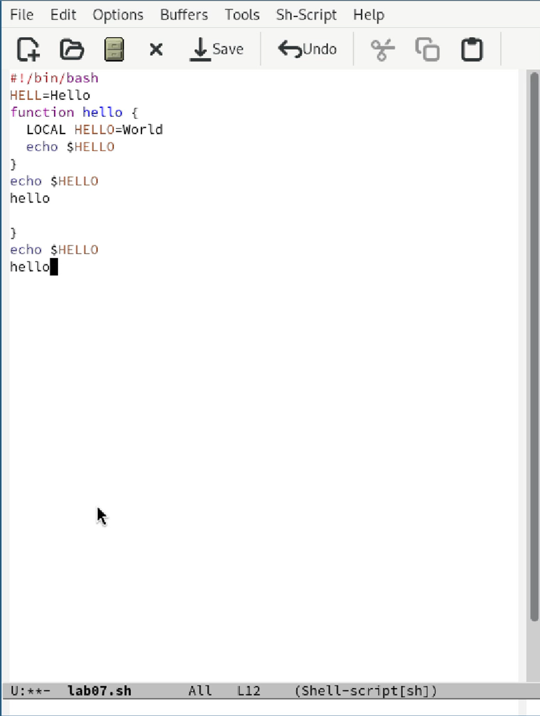

Закрываем это окно

## 7.4. Теперь вновь переключайтесь между буферами, но уже без вывода их списка на экран (C-x b).

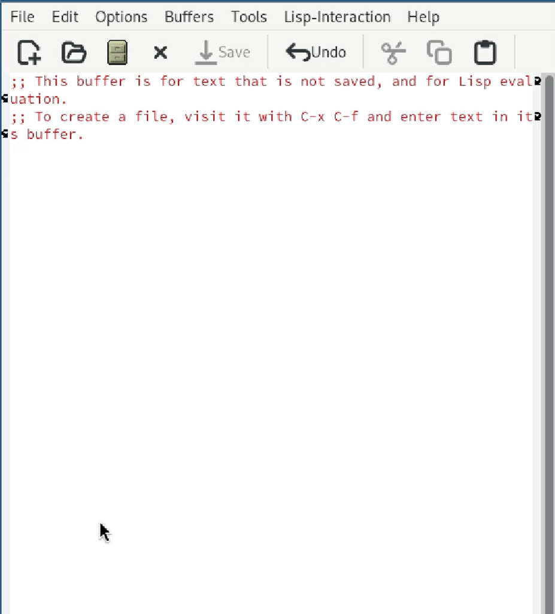

Переключаемся между буферами без списка

## 8. Управление окнами.

## 8.1. Поделите фрейм на 4 части: разделите фрейм на два окна по вертикали (C-x 3), а затем каждое из этих окон на две части по горизонтали (C-x 2).

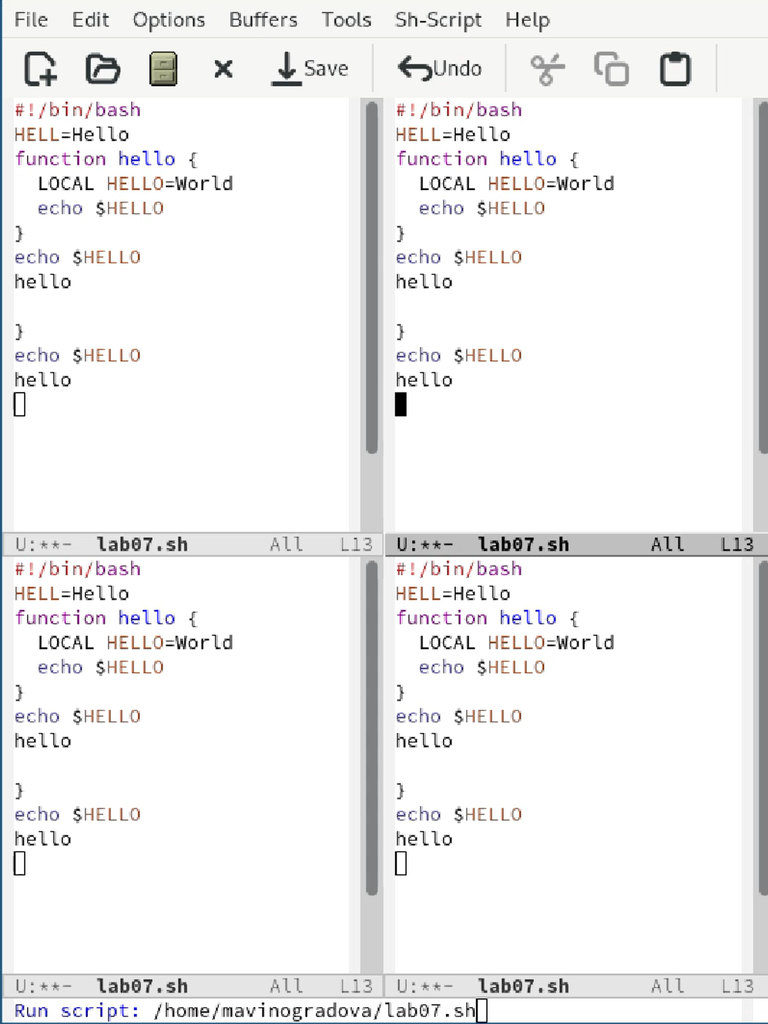

## 8.2. В каждом из четырёх созданных окон откройте новый буфер (файл) и введите несколько строк текста.

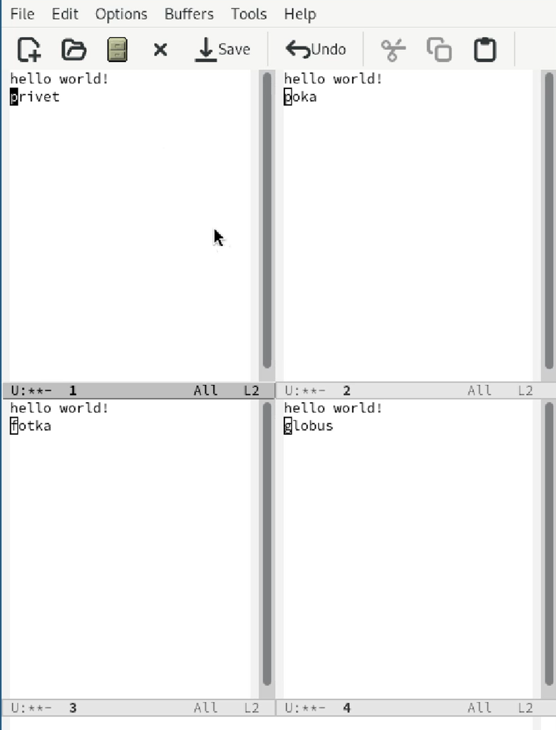

Создаем новые файлы и пишем в них пару строчек текста

## 9. Режим поиска

## 9.1. Переключитесь в режим поиска (C-s) и найдите несколько слов, присутствующих в тексте.

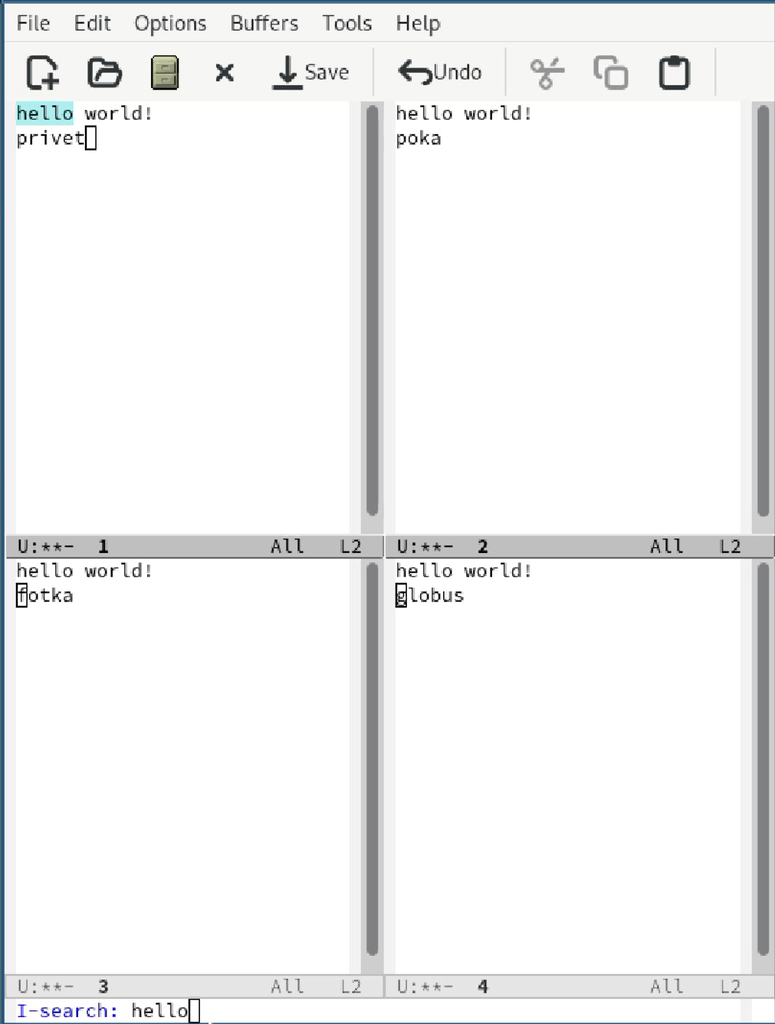

Переключаемся в режим поиска

## 9.2. Переключайтесь между результатами поиска, нажимая C-s.

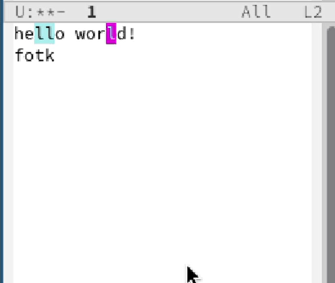

Переключаемся между результатами поиска

## 9.3. Выйдите из режима поиска, нажав C-g.

## 9.4. Перейдите в режим поиска и замены (M-%), введите текст, который следует найти и заменить, нажмите Enter , затем введите текст для замены. После того как будут подсвечены результаты поиска, нажмите ! для подтверждения замены.

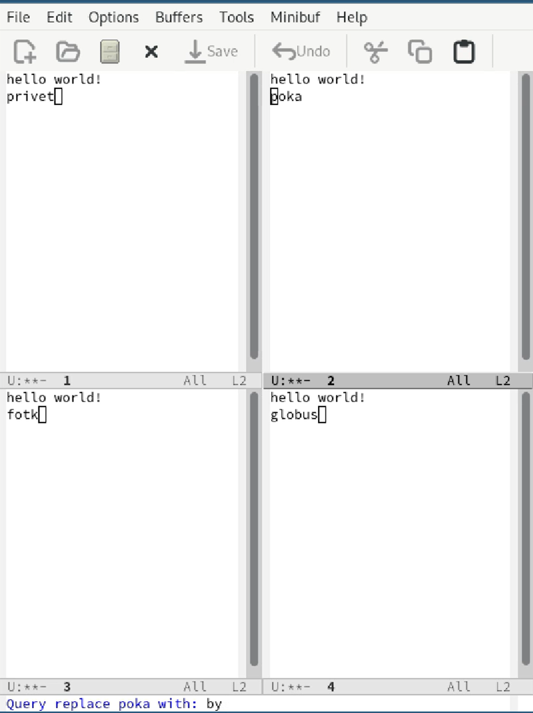

Заменяем слово

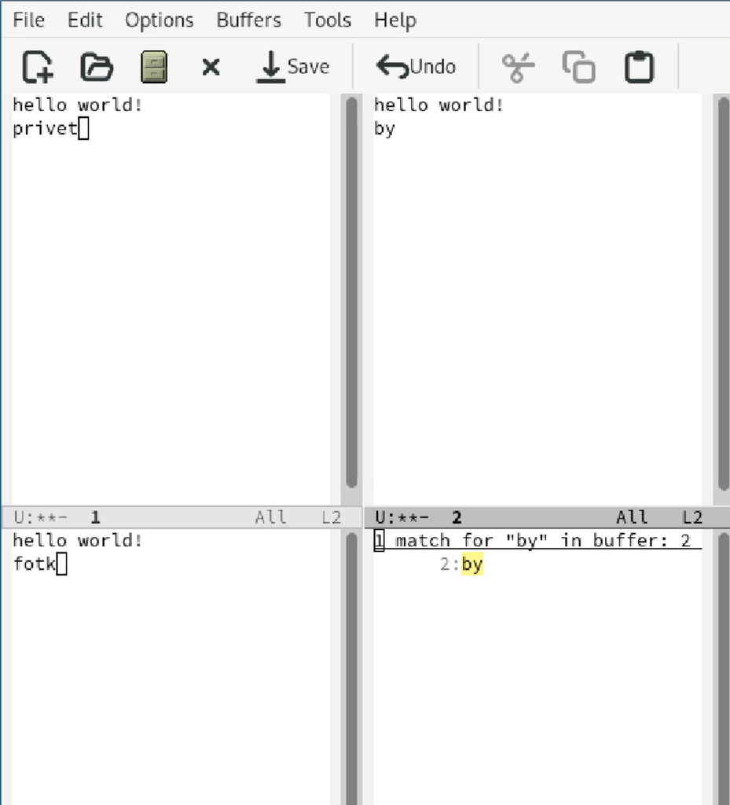

Используем другой режим поиска

## Вывод

В ходе работы освоены базовые принципы работы в Linux и основные функции редактора Emacs, включая работу с буферами, окнами и использование горячих клавиш. Приобретённые навыки позволяют эффективно редактировать тексты и настраивать среду под индивидуальные задачи. Emacs продемонстрировал широкие возможности для программирования и обработки текстов в Linux-системах. Полученный опыт будет полезен для дальнейшей работы в командной строке.